# Finding sub groups within a data set

## A walkthrough for K-Means clustering

Often we have access to a data set that we surmise (or are told) contains information from various subgroups. The data represents 125 distinct events.

Take columns 4, 5, and 6 from the provided data.csv and determine if subgroups do in fact exist, and if so how to define them.

```python
from IPython.display import Image
import os
import matplotlib
%matplotlib inline
import matplotlib.pyplot as plt
from sklearn import cluster, decomposition
from mpl_toolkits.mplot3d import Axes3D
font = {'size': 20}
matplotlib.rc('font', **font)

curdir = !pwd
rootdir = os.path.abspath(curdir[0])

def get_columns(columns):
    with open(os.path.join(rootdir, 'data.csv')) as f:
        for line in f:
            yield [line.split(',')[i - 1] for i in columns]
```

## The timeseries view

Timeseries graphs are the most prevalent visualization of data, but they are limited in their ability to display the interconnection between metrics.

Questions:

- For data from columns 4, 5, and 6 can you determine if there are distinct groupings?
- How many groups?
- How would you define the separation between groups?

```python
def timeseries(col):
    """ Make a simple timeseries view of a column """
    data = np.array(list(get_columns([col])), dtype=np.float)
    fig = plt.figure(figsize=(15,8))
    ax = plt.subplot(111)
    plt.grid(lw=2)
    plt.plot(data, 'bo')
    plt.xlabel("Column %d" % col)
    plt.show()
```

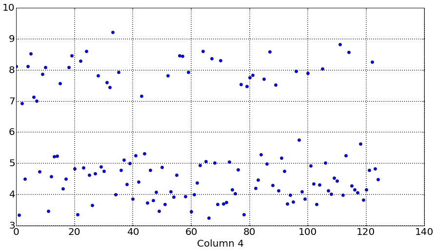

```python
timeseries(4)
```

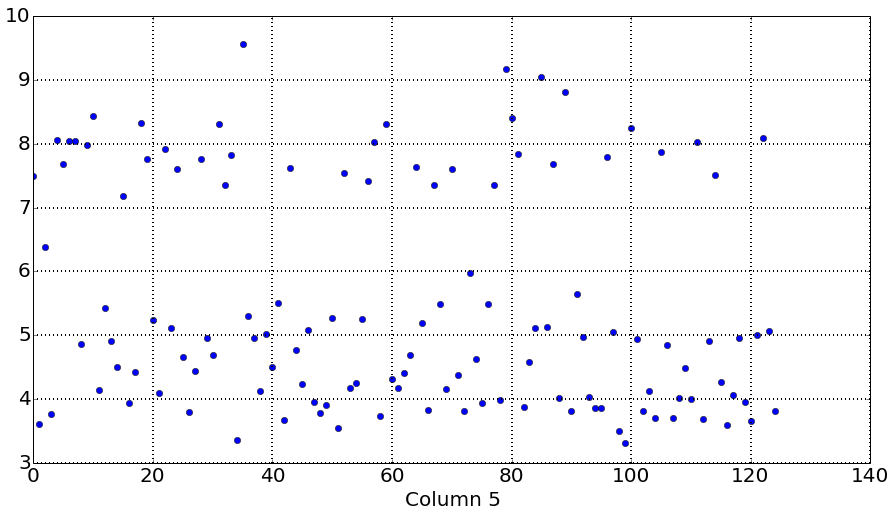

```python
timeseries(5)
```

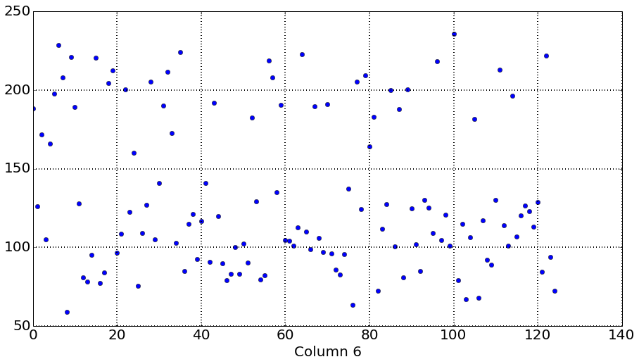

```python
timeseries(6)
```

## Inspect the distribution of each column

```python
def histogram(col):
    """ Flatten the timeseries """
    data = np.array(list(get_columns([col])), dtype=np.float)
    fig = plt.figure(figsize=(15,8))
    ax = plt.subplot(111)
    plt.grid(lw=2)
    plt.hist(data, bins=20)
    plt.xlabel("Column %d" % col)
    plt.show()
```

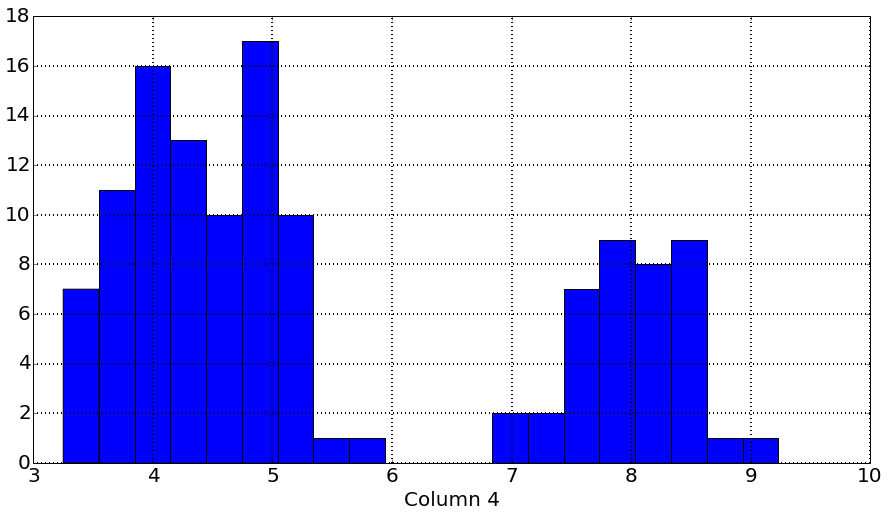

```python
histogram(4)
```

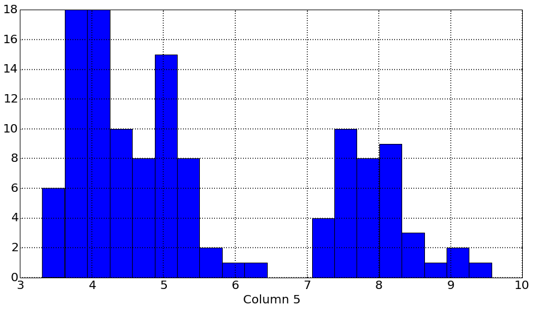

```python
histogram(5)
```

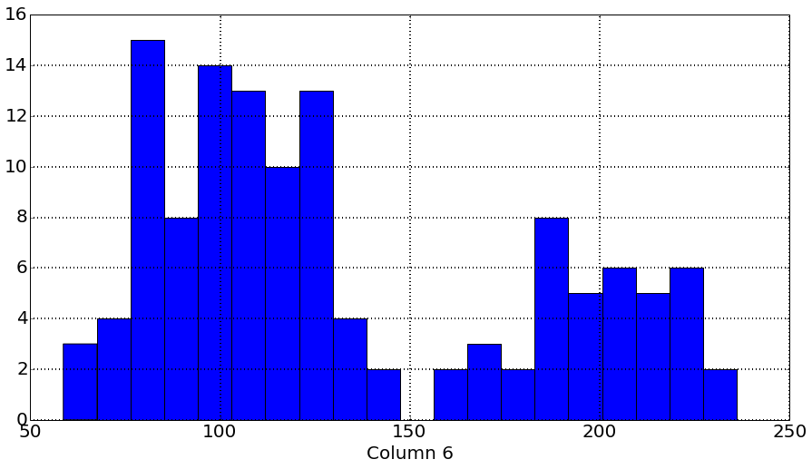

```python
histogram(6)
```

## Questions

- Are there subgroups to the data?
- How confident are you in you conclusion?
- If so how many subgroups do you think?
- How would you quantify the difference between subgroups?
- Do all data points in the sample conform to the group separation?

## Verify separation between groups

To the group separations for each column agree? (Do subgroups according to column 4 agree with column groupings for 5 and 6?)

```python
def scatter(x, y):
    data = np.array(list(get_columns([x,y])), dtype=np.float)
    fig = plt.figure(figsize=(15,8))
    ax = plt.subplot(111)
    plt.grid(lw=2)
    plt.plot(data[:,0], data[:,1], 'bo')
    plt.xlabel("Column %d" % x)
    plt.ylabel("Column %d" % y)
    plt.show()
```

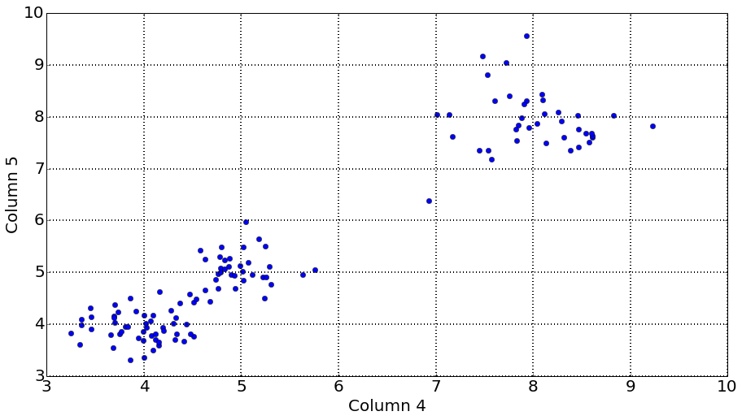

```python
scatter(4,5)
```

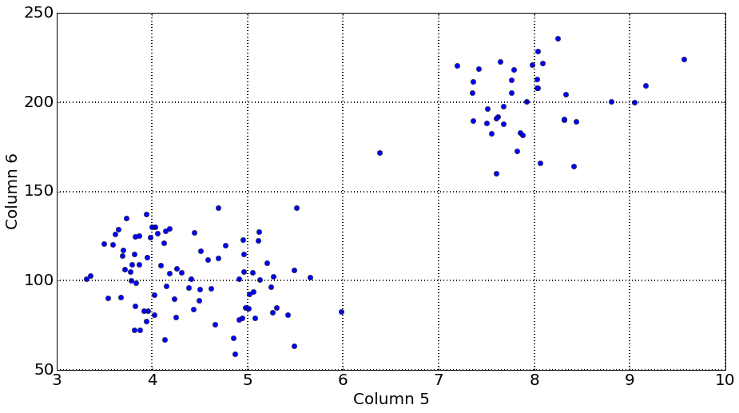

```python
scatter(5,6)
```

## Creating a more informative data representation

Instead of looking at multiple charts, can all the data be represented in a single chart?

```python
def scatter3d(x,y,z):
    """ Scatter plots, now it 3D! """
    data = np.array(list(get_columns([x,y,z])), dtype=np.float)
    fig = plt.figure(figsize=(15,8))
    ax = fig.add_subplot(111, projection='3d')
    plt.plot(data[:,0], data[:,1], data[:,2], 'bo')
    ax.set_xlabel('Column %d' % x)
    ax.set_ylabel('Column %d' % y)
    ax.set_zlabel('Column %d' % z)
    grid_wt = 0.5
    ax.w_xaxis._axinfo.update({'grid' : {'color': (0, 0, 0, grid_wt)}})
    ax.w_yaxis._axinfo.update({'grid' : {'color': (0, 0, 0, grid_wt)}})
    ax.w_zaxis._axinfo.update({'grid' : {'color': (0, 0, 0, grid_wt)}})
    plt.grid(lw=2)
    plt.show()
```

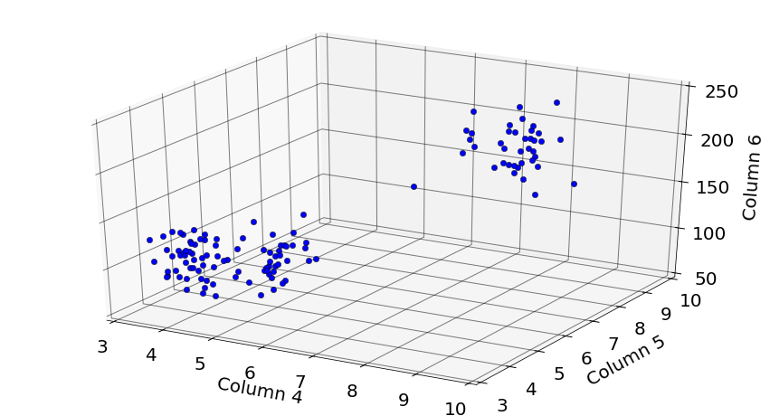

```python
scatter3d(4,5,6)
```

- Can we choose an objective method of creating the clusters?

## Types of clustering

It's important to recogize that there is not just one clustering technique that always works. There are a wide variety of methods and each has their own set of advantages and disadvantages. Getting a feel for the type of data you are working with prior to applying a algorithm can help you make an informed decision.

Here's a nice visualization from scikit-learn on six different clustering algorithm and how they perform given four very different distributions of data.

```python
Image(url='http://scikit-learn.org/0.11/_images/plot_cluster_comparison_11.png')
```

[figure not shown]

## K-Means Clustering

Given a set of observations $(x_1, x_2, ..., x_n)$, where each observation is a d-dimensional real vector, k-means clustering aims to partition the n observations into k sets where $(k \leq n)$ and $\boldsymbol S = {S_1, S_2, ..., S_k}$ so as to minimize the within-cluster sum of squares (WCSS):

$\displaystyle \underset{\mathbf{S}} {\operatorname{arg\,min}} \sum_{i=1}^{k} \sum_{\mathbf x_j \in S_i} \left\| \mathbf x_j - \boldsymbol\mu_i \right\|^2 $

where $\boldsymbol\mu_i$ is the mean of points in $S_i$.

source: http://en.wikipedia.org/wiki/K-means_clustering

## The idea behind the algorithm

- Points get assigned to the center that their closest to as measured by the (euclidean) distance.
- The algorithm iteratively shifts the centers to get closest to all the points in it's cluster.

## A Walkthrough of the K-Means Algorithm

Here, we'll walk through the K-Means clustering algorithm with a 2 dimensional data set to get a feel for how it works and then apply the algorithm on our data set via the scikit-learn module.

```python
def create_points(sets):
    """
    Create test data points for a list of groups
    """
    def gen(n, mu, s):
        return np.random.randn(n * 2).reshape(n, 2) * s + np.array(mu)

    pts = None
    for idx, s in enumerate(sets):
        if pts is None:
            pts = np.hstack([gen(*s), idx * np.ones((s[0],1))])
        else:
            new_pts = np.hstack([gen(*s), idx * np.ones((s[0],1))])
            pts = np.vstack([pts, new_pts])

    np.random.shuffle(pts)
    return pts

def calc_labels(centers, pts):
    """
    Label the points based on the current approximation of the cluster centers
    """
    for pt in pts[:,:2]:
        ss = np.inf
        label = None
        for idx, c in enumerate(np.array(centers)):
            dist = pt - c
            new_ss = np.sum(dist * dist)
            if new_ss < ss:
                label = idx
                ss = new_ss
        yield label

def scatter(pts, centers=None, title=None, find_groups=False):
    """
    Viz the data.  Optionally show the center locations and color code the points.
    """
    colors = 'brygk'
    markers = 'o^s*+'
    fig = plt.figure(figsize=(15,8))
    ax = plt.subplot(111)
    plt.grid(lw=2)
    for g in np.unique(pts[:,2]):
        kwargs = {
            'marker': markers[int(g)],
            's': 120,
        }
        if find_groups:
            kwargs['c'] = [colors[int(i)] for i in calc_labels(centers, pts[pts[:,2] == g])]
        plt.scatter(
            pts[pts[:,2] == g][:,0],
            pts[pts[:,2] == g][:,1],
            **kwargs)
    if centers is not None:
        for idx, center in enumerate(centers):
            plt.text(*center, s='ABCDEF'[idx])

    if title:
        plt.title(title)
    ax.set_aspect('equal')
    plt.show()
```

## Create a sample data set

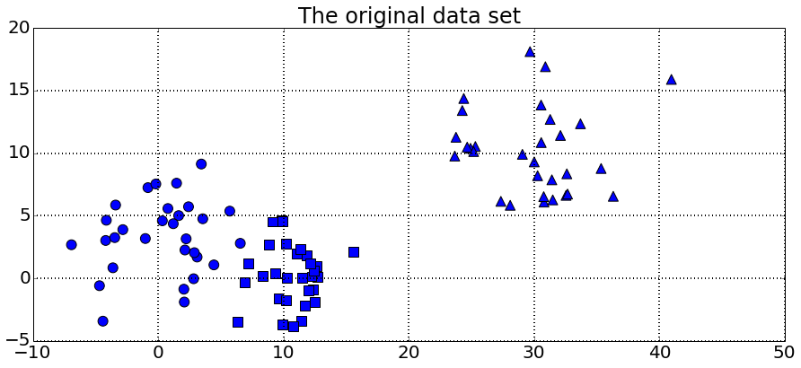

```python
sets = [
    (30, (0, 5), 4),
    (30, (30, 10), 4),
    (30, (10, 0), 2),
]
pts = create_points(sets)
scatter(pts, title='The original data set')
```

## Start with random center locations

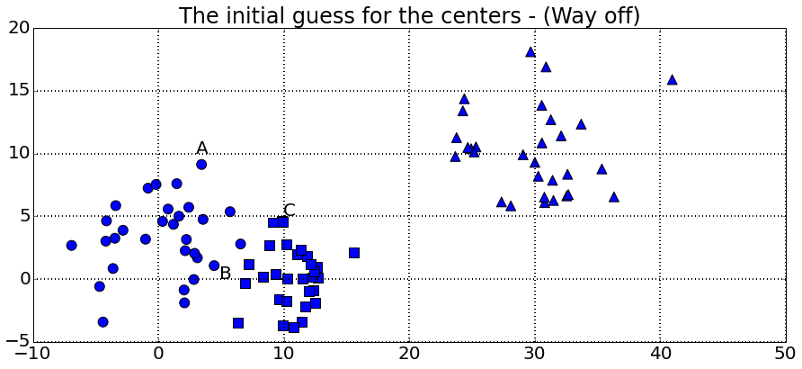

```python
centers = [
    (3,10),
    (5,0),
    (10,5),
]
scatter(pts, centers, title='The initial guess for the centers - (Way off)')
```

## Assign each data point to the center that it's closest to

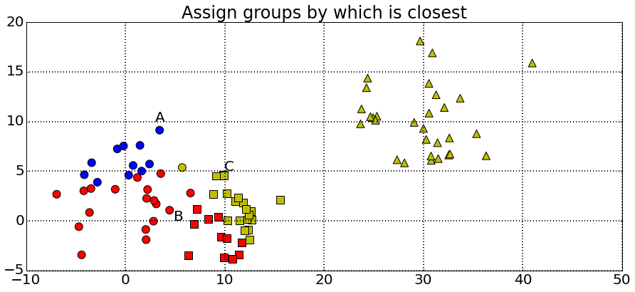

```python
scatter(pts, centers, title='Assign groups by which is closest', find_groups=True)
```

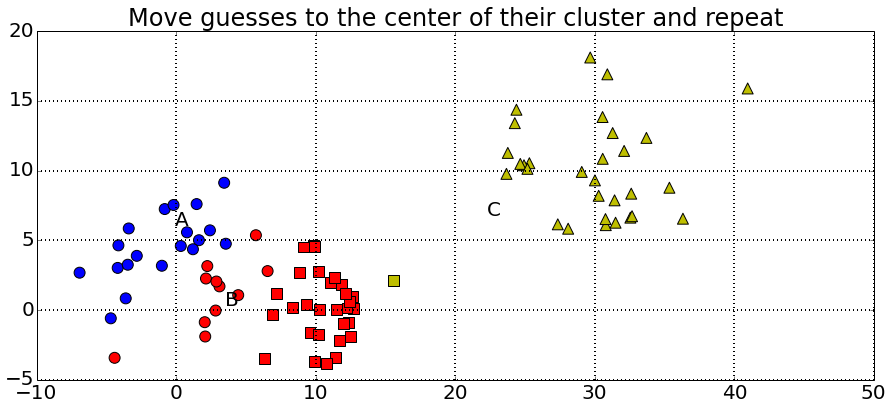

```python
labels = np.array([g for g in calc_labels(centers, pts)])
new_centers = []
for idx, c in enumerate(centers):
    new_centers.append(tuple(pts[labels == idx][:, :2].mean(axis=0)))
centers = new_centers
scatter(pts, centers, title='Move guesses to the center of their cluster and repeat', find_groups=True)
```

## Apply K-Means to the Original Dataset

Now that we have an idea of what the algorithm is doing behind the scenes, use the scikit-learn module to cluster our original data set from columns 4, 5, and 6

```python
def clustering(x, y, z, groups=2, normalize=False):
    """ Show the K-Means clustering result with optional normalization and number of clusters """
    data = np.array(list(get_columns([x,y,z])), dtype=np.float)

    if normalize:
        data = (data - data.mean(axis=0)) / data.std(axis=0)

    kmeans = cluster.KMeans(n_clusters=groups, n_init=15)
    kmeans.fit(data)

    colors = 'rbyg'

    fig = plt.figure(figsize=(15,8))
    ax = fig.add_subplot(111, projection='3d')
    ax.scatter(data[:,0], data[:,1], data[:,2], marker='o', c=[colors[g] for g in kmeans.labels_], alpha=0.7, s=40)
    ax.set_xlabel('Column %d' % x)
    ax.set_ylabel('Column %d' % y)
    ax.set_zlabel('Column %d' % z)
    grid_wt = 0.5
    ax.w_xaxis._axinfo.update({'grid' : {'color': (0, 0, 0, grid_wt)}})
    ax.w_yaxis._axinfo.update({'grid' : {'color': (0, 0, 0, grid_wt)}})
    ax.w_zaxis._axinfo.update({'grid' : {'color': (0, 0, 0, grid_wt)}})
    plt.grid(lw=2)
    plt.show()
```

### 2 group cluster

No preprocessing here, give me 2 clusters

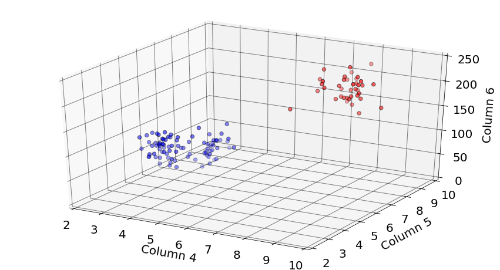

```python
clustering(4,5,6)
```

### Can the algorithm find additional subgroups?

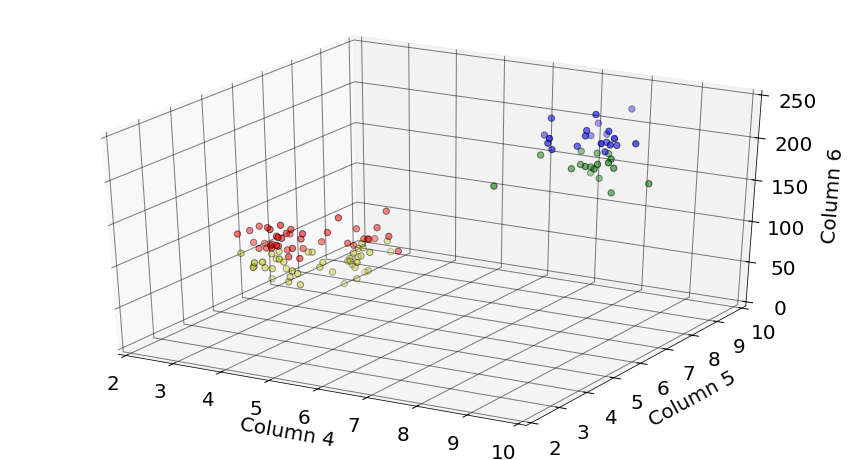

```python
clustering(4,5,6,groups=4)
```

- Why were the groupings both split vertically?
- What can be done to correct for this bias?

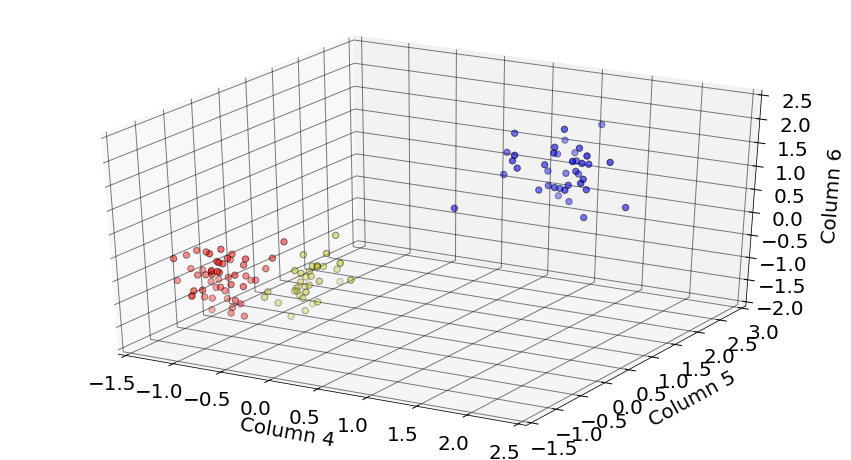

```python
clustering(4,5,6,groups=3,normalize=True)
```

Questions:

- What areas of this model should you not trust the outcome?
- To be used on new data points, what additional information is required along with the model?

## Higer order data

This data set happened to only have 3 metrics corresponding to a 3 dimensional graph.

- How can we represent an n-dimensional data in less than an n dimensional space?
- Take the three dimensional data and reduce it to two dimensions

```python
def principal_component_analysis(cols, groups=2, normalize=False):
    data = np.array(list(get_columns(cols)), dtype=np.float)

    if normalize:
        data = (data - data.mean(axis=0)) / data.std(axis=0)

    pca = decomposition.PCA(n_components=2)
    pca.fit(data)
    X = pca.transform(data)

    kmeans = cluster.KMeans(n_clusters=groups, n_init=15)
    kmeans.fit(data)

    colors = 'rbyg'

    fig = plt.figure(figsize=(15,8))
    ax = plt.subplot(111)
    plt.grid(lw=2)
    plt.scatter(X[:,0], X[:,1], marker='o', c=[colors[g] for g in kmeans.labels_], alpha=0.7, s=40)
    ldata = (pca.components_[0][0], cols[0], pca.components_[0][1], cols[1], pca.components_[0][2], cols[2])
    plt.xlabel("x = %g(C%d) %+g(C%d) %+g(C%d)" % ldata)
    ldata = (pca.components_[1][0], cols[0], pca.components_[1][1], cols[1], pca.components_[1][2], cols[2])
    plt.ylabel("y = %g(C%d) %+g(C%d) %+g(C%d)" % ldata)
    plt.show()
```

## The goal here is to find a plane through the data that preserves the most variation between the points

From the plots above, a diagonal slice will probably work best

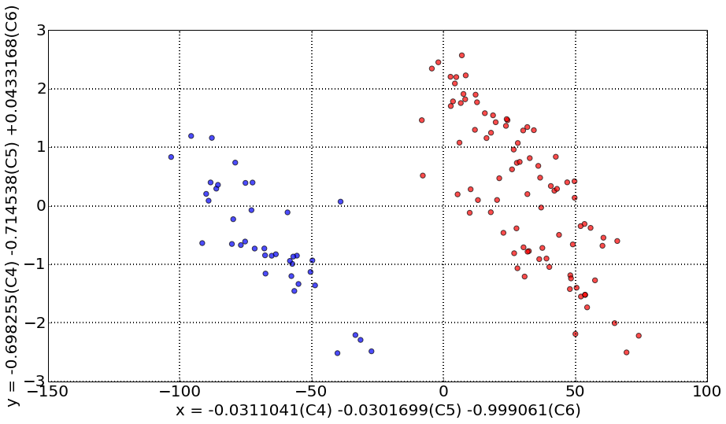

```python
principal_component_analysis([4,5,6])
```

The new $x$ and $y$ are a linear combination of the three columns with the new $x$ is mostly a mappping from column 6.

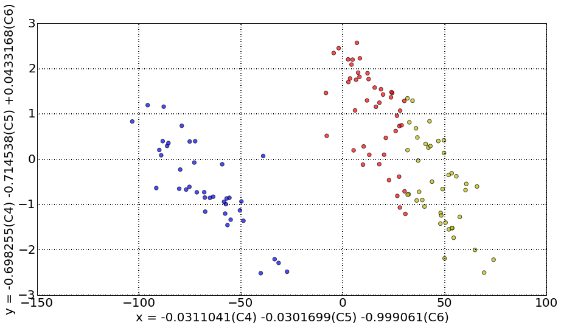

```python
principal_component_analysis([4,5,6],groups=3)
```

The two larger clusters are pretty clear, but since the data wasn't normalized C6 gets the most attention and same "vertical" split appears as in the 3d representation.

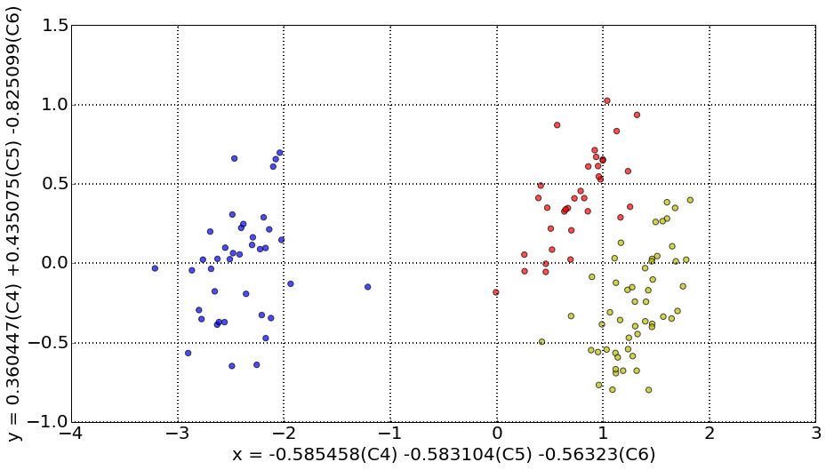

```python
principal_component_analysis([4,5,6],groups=3,normalize=True)
```

Not quite as clear a view into the two smaller clusters

### Questions

- What are the advantages and/or disadvantages to using dimensionality reduction?
- How could you quantify any loss of fidelity?
- Since this a linearized operation, how do you quantify the errors from nonlinear data sets?

# Wrap Up

The three groupings seem to be the most appropriate clustering and was reasonably straight forward to validate with the 3D graph.

- Without dimensionality reduction and associated data loss, how can you use the model's inertia measurement to assess it's accuracy?
- Would this approach be possible for labeled data?
- What effect would using discrete data with limited resolution (like 1,0,0,1,1,1,0,0,2,2,0) have?
- How do you determine the best number of clusters to use?
- How do you implement the use of the model with new data?
- Can you build in methods for tracking the model's accuracy on with new data?
- Normalizing the data is very important. If the distance between the top cluster and the bottom two clusters (as seen in the 3D view) is drastically increased, would that affect the algorithm's effectiveness?